# Part I - (Analysis of the Prosper Loan Dataset)

## Introduction

> This data set gives information on 113,937 loans given by Prosper with 81 variables on each loan, including loan amount, borrower rate (or interest rate), current loan status, borrower income, and many others from 2005 to 2014. The data set provides details on general borrower information and performances of the loans.

## Preliminary Wrangling

Reviewing and exploring data set with code to make required changes before analysis and visualization

```python
# import all packages and set plots to be embedded inline
import numpy as np
import pandas as pd
import matplotlib.pyplot as plt
import seaborn as sb

%matplotlib inline
```

```python
#Loading the dataset
df= pd.read_csv('prosperLoanData.csv')
df.head()
```

|  | ListingKey | ListingNumber | ListingCreationDate | CreditGrade | Term | LoanStatus | ClosedDate | BorrowerAPR | BorrowerRate | LenderYield | ... | LP_ServiceFees | LP_CollectionFees | LP_GrossPrincipalLoss | LP_NetPrincipalLoss | LP_NonPrincipalRecoverypayments | PercentFunded | Recommendations | InvestmentFromFriendsCount | InvestmentFromFriendsAmount | Investors |
| --- | --- | --- | --- | --- | --- | --- | --- | --- | --- | --- | --- | --- | --- | --- | --- | --- | --- | --- | --- | --- | --- |
| 0 | 1021339766868145413AB3B | 193129 | 2007-08-26 19:09:29.263000000 | C | 36 | Completed | 2009-08-14 00:00:00 | 0.16516 | 0.1580 | 0.1380 | ... | -133.18 | 0.0 | 0.0 | 0.0 | 0.0 | 1.0 | 0 | 0 | 0.0 | 258 |
| 1 | 10273602499503308B223C1 | 1209647 | 2014-02-27 08:28:07.900000000 | NaN | 36 | Current | NaN | 0.12016 | 0.0920 | 0.0820 | ... | 0.00 | 0.0 | 0.0 | 0.0 | 0.0 | 1.0 | 0 | 0 | 0.0 | 1 |
| 2 | 0EE9337825851032864889A | 81716 | 2007-01-05 15:00:47.090000000 | HR | 36 | Completed | 2009-12-17 00:00:00 | 0.28269 | 0.2750 | 0.2400 | ... | -24.20 | 0.0 | 0.0 | 0.0 | 0.0 | 1.0 | 0 | 0 | 0.0 | 41 |
| 3 | 0EF5356002482715299901A | 658116 | 2012-10-22 11:02:35.010000000 | NaN | 36 | Current | NaN | 0.12528 | 0.0974 | 0.0874 | ... | -108.01 | 0.0 | 0.0 | 0.0 | 0.0 | 1.0 | 0 | 0 | 0.0 | 158 |
| 4 | 0F023589499656230C5E3E2 | 909464 | 2013-09-14 18:38:39.097000000 | NaN | 36 | Current | NaN | 0.24614 | 0.2085 | 0.1985 | ... | -60.27 | 0.0 | 0.0 | 0.0 | 0.0 | 1.0 | 0 | 0 | 0.0 | 20 |

5 rows × 81 columns

```python
#Checking for the rows and columns in the dataset
df.shape
```

```
(113937, 81)
```

```python
#Checking for the datatypes of each column
df.dtypes
```

```
ListingKey                              object
ListingNumber                            int64
ListingCreationDate                     object
CreditGrade                             object
Term                                     int64
LoanStatus                              object
ClosedDate                              object
BorrowerAPR                            float64
BorrowerRate                           float64
LenderYield                            float64
EstimatedEffectiveYield                float64
EstimatedLoss                          float64
EstimatedReturn                        float64
ProsperRating (numeric)                float64
ProsperRating (Alpha)                   object
ProsperScore                           float64
ListingCategory (numeric)                int64
BorrowerState                           object
Occupation                              object
EmploymentStatus                        object
EmploymentStatusDuration               float64
IsBorrowerHomeowner                       bool
CurrentlyInGroup                          bool
GroupKey                                object
DateCreditPulled                        object
CreditScoreRangeLower                  float64
CreditScoreRangeUpper                  float64
FirstRecordedCreditLine                 object
CurrentCreditLines                     float64
OpenCreditLines                        float64
                                        ...
TotalProsperLoans                      float64
TotalProsperPaymentsBilled             float64
OnTimeProsperPayments                  float64
ProsperPaymentsLessThanOneMonthLate    float64
ProsperPaymentsOneMonthPlusLate        float64
ProsperPrincipalBorrowed               float64
ProsperPrincipalOutstanding            float64
ScorexChangeAtTimeOfListing            float64
LoanCurrentDaysDelinquent                int64
LoanFirstDefaultedCycleNumber          float64
LoanMonthsSinceOrigination               int64
LoanNumber                               int64
LoanOriginalAmount                       int64
LoanOriginationDate                     object
LoanOriginationQuarter                  object
MemberKey                               object
MonthlyLoanPayment                     float64
LP_CustomerPayments                    float64
LP_CustomerPrincipalPayments           float64
LP_InterestandFees                     float64
LP_ServiceFees                         float64
LP_CollectionFees                      float64
LP_GrossPrincipalLoss                  float64
LP_NetPrincipalLoss                    float64
LP_NonPrincipalRecoverypayments        float64
PercentFunded                          float64
Recommendations                          int64
InvestmentFromFriendsCount               int64
InvestmentFromFriendsAmount            float64
Investors                                int64
Length: 81, dtype: object
```

```python
#Getting the summary statistics of the numerical columns in the data set
df.describe()
```

|  | ListingNumber | Term | BorrowerAPR | BorrowerRate | LenderYield | EstimatedEffectiveYield | EstimatedLoss | EstimatedReturn | ProsperRating (numeric) | ProsperScore | ... | LP_ServiceFees | LP_CollectionFees | LP_GrossPrincipalLoss | LP_NetPrincipalLoss | LP_NonPrincipalRecoverypayments | PercentFunded | Recommendations | InvestmentFromFriendsCount | InvestmentFromFriendsAmount | Investors |
| --- | --- | --- | --- | --- | --- | --- | --- | --- | --- | --- | --- | --- | --- | --- | --- | --- | --- | --- | --- | --- | --- |
| count | 1.139370e+05 | 113937.000000 | 113912.000000 | 113937.000000 | 113937.000000 | 84853.000000 | 84853.000000 | 84853.000000 | 84853.000000 | 84853.000000 | ... | 113937.000000 | 113937.000000 | 113937.000000 | 113937.000000 | 113937.000000 | 113937.000000 | 113937.000000 | 113937.000000 | 113937.000000 | 113937.000000 |
| mean | 6.278857e+05 | 40.830248 | 0.218828 | 0.192764 | 0.182701 | 0.168661 | 0.080306 | 0.096068 | 4.072243 | 5.950067 | ... | -54.725641 | -14.242698 | 700.446342 | 681.420499 | 25.142686 | 0.998584 | 0.048027 | 0.023460 | 16.550751 | 80.475228 |
| std | 3.280762e+05 | 10.436212 | 0.080364 | 0.074818 | 0.074516 | 0.068467 | 0.046764 | 0.030403 | 1.673227 | 2.376501 | ... | 60.675425 | 109.232758 | 2388.513831 | 2357.167068 | 275.657937 | 0.017919 | 0.332353 | 0.232412 | 294.545422 | 103.239020 |
| min | 4.000000e+00 | 12.000000 | 0.006530 | 0.000000 | -0.010000 | -0.182700 | 0.004900 | -0.182700 | 1.000000 | 1.000000 | ... | -664.870000 | -9274.750000 | -94.200000 | -954.550000 | 0.000000 | 0.700000 | 0.000000 | 0.000000 | 0.000000 | 1.000000 |
| 25% | 4.009190e+05 | 36.000000 | 0.156290 | 0.134000 | 0.124200 | 0.115670 | 0.042400 | 0.074080 | 3.000000 | 4.000000 | ... | -73.180000 | 0.000000 | 0.000000 | 0.000000 | 0.000000 | 1.000000 | 0.000000 | 0.000000 | 0.000000 | 2.000000 |
| 50% | 6.005540e+05 | 36.000000 | 0.209760 | 0.184000 | 0.173000 | 0.161500 | 0.072400 | 0.091700 | 4.000000 | 6.000000 | ... | -34.440000 | 0.000000 | 0.000000 | 0.000000 | 0.000000 | 1.000000 | 0.000000 | 0.000000 | 0.000000 | 44.000000 |
| 75% | 8.926340e+05 | 36.000000 | 0.283810 | 0.250000 | 0.240000 | 0.224300 | 0.112000 | 0.116600 | 5.000000 | 8.000000 | ... | -13.920000 | 0.000000 | 0.000000 | 0.000000 | 0.000000 | 1.000000 | 0.000000 | 0.000000 | 0.000000 | 115.000000 |
| max | 1.255725e+06 | 60.000000 | 0.512290 | 0.497500 | 0.492500 | 0.319900 | 0.366000 | 0.283700 | 7.000000 | 11.000000 | ... | 32.060000 | 0.000000 | 25000.000000 | 25000.000000 | 21117.900000 | 1.012500 | 39.000000 | 33.000000 | 25000.000000 | 1189.000000 |

8 rows × 61 columns

```python
#Getting information on entries in the data set, to see columns with null values
df.info()
```

```
<class 'pandas.core.frame.DataFrame'>
RangeIndex: 113937 entries, 0 to 113936
Data columns (total 81 columns):
ListingKey                             113937 non-null object
ListingNumber                          113937 non-null int64
ListingCreationDate                    113937 non-null object
CreditGrade                            28953 non-null object
Term                                   113937 non-null int64
LoanStatus                             113937 non-null object
ClosedDate                             55089 non-null object
BorrowerAPR                            113912 non-null float64
BorrowerRate                           113937 non-null float64
LenderYield                            113937 non-null float64
EstimatedEffectiveYield                84853 non-null float64
EstimatedLoss                          84853 non-null float64
EstimatedReturn                        84853 non-null float64
ProsperRating (numeric)                84853 non-null float64
ProsperRating (Alpha)                  84853 non-null object
ProsperScore                           84853 non-null float64
ListingCategory (numeric)              113937 non-null int64
BorrowerState                          108422 non-null object
Occupation                             110349 non-null object
EmploymentStatus                       111682 non-null object
EmploymentStatusDuration               106312 non-null float64
IsBorrowerHomeowner                    113937 non-null bool
CurrentlyInGroup                       113937 non-null bool
GroupKey                               13341 non-null object
DateCreditPulled                       113937 non-null object
CreditScoreRangeLower                  113346 non-null float64
CreditScoreRangeUpper                  113346 non-null float64
FirstRecordedCreditLine                113240 non-null object
CurrentCreditLines                     106333 non-null float64
OpenCreditLines                        106333 non-null float64
TotalCreditLinespast7years             113240 non-null float64
OpenRevolvingAccounts                  113937 non-null int64
OpenRevolvingMonthlyPayment            113937 non-null float64
InquiriesLast6Months                   113240 non-null float64
TotalInquiries                         112778 non-null float64
CurrentDelinquencies                   113240 non-null float64
AmountDelinquent                       106315 non-null float64
```

[output cut: 31 more lines]

```
LP_CustomerPayments                    113937 non-null float64
LP_CustomerPrincipalPayments           113937 non-null float64
LP_InterestandFees                     113937 non-null float64
LP_ServiceFees                         113937 non-null float64
LP_CollectionFees                      113937 non-null float64
LP_GrossPrincipalLoss                  113937 non-null float64
LP_NetPrincipalLoss                    113937 non-null float64
LP_NonPrincipalRecoverypayments        113937 non-null float64
PercentFunded                          113937 non-null float64
Recommendations                        113937 non-null int64
InvestmentFromFriendsCount             113937 non-null int64
InvestmentFromFriendsAmount            113937 non-null float64
Investors                              113937 non-null int64
dtypes: bool(3), float64(50), int64(11), object(17)
memory usage: 68.1+ MB
```

```python
#Checking for duplicates in the dataset
df[df.duplicated()]
```

|  | ListingKey | ListingNumber | ListingCreationDate | CreditGrade | Term | LoanStatus | ClosedDate | BorrowerAPR | BorrowerRate | LenderYield | ... | LP_ServiceFees | LP_CollectionFees | LP_GrossPrincipalLoss | LP_NetPrincipalLoss | LP_NonPrincipalRecoverypayments | PercentFunded | Recommendations | InvestmentFromFriendsCount | InvestmentFromFriendsAmount | Investors |
| --- | --- | --- | --- | --- | --- | --- | --- | --- | --- | --- | --- | --- | --- | --- | --- | --- | --- | --- | --- | --- | --- |

0 rows × 81 columns

### Exploration and wrangling of the Term column

```python
#Checking for the various loan periods
df.Term.value_counts()
```

```
36    87778
60    24545
12     1614
Name: Term, dtype: int64
```

```python
#Checking for the datatype of the column
df.Term.dtype
```

```
dtype('int64')
```

```python
# Allocating the various loan periods to a category
df.Term = df.Term.map({12: 'Short', 36: 'Medium', 60:'Long'})
```

```python
#Converting the datatype of the term column to Category
df.Term = df["Term"].astype("category")
```

```python
#Checking if the operation above worked
df.Term.value_counts()
```

```
Medium    87778
Long      24545
Short      1614
Name: Term, dtype: int64
```

```python
df.Term.dtype
```

```
CategoricalDtype(categories=['Long', 'Medium', 'Short'], ordered=False)
```

### Exploration and wrangling of the Loan Status column

```python
# Checking for nulls in the Loan Status Column
df[df.LoanStatus.isnull()]
```

|  | ListingKey | ListingNumber | ListingCreationDate | CreditGrade | Term | LoanStatus | ClosedDate | BorrowerAPR | BorrowerRate | LenderYield | ... | LP_ServiceFees | LP_CollectionFees | LP_GrossPrincipalLoss | LP_NetPrincipalLoss | LP_NonPrincipalRecoverypayments | PercentFunded | Recommendations | InvestmentFromFriendsCount | InvestmentFromFriendsAmount | Investors |
| --- | --- | --- | --- | --- | --- | --- | --- | --- | --- | --- | --- | --- | --- | --- | --- | --- | --- | --- | --- | --- | --- |

0 rows × 81 columns

```python
#Checking the number of unique values in the Loan Status column
df.LoanStatus.value_counts()
```

```
Current                   56576
Completed                 38074
Chargedoff                11992
Defaulted                  5018
Past Due (1-15 days)        806
Past Due (31-60 days)       363
Past Due (61-90 days)       313
Past Due (91-120 days)      304
Past Due (16-30 days)       265
FinalPaymentInProgress      205
Past Due (>120 days)         16
Cancelled                     5
Name: LoanStatus, dtype: int64
```

```python
# Changing all past due dates to 'past due'
df.LoanStatus = df.LoanStatus.replace({'Past Due (1-15 days)':'Past Due', 'Past Due (16-30 days)':'Past Due',
                  'Past Due (31-60 days)':'Past Due', 'Past Due (61-90 days)' :'Past Due',
                  'Past Due (91-120 days)' :'Past Due', 'Past Due (>120 days)' :'Past Due'})
```

```python
#Changing the data type of the Loan Status column from int to category
df.LoanStatus = df.LoanStatus.astype('category')
print(df.LoanStatus.dtype)
```

```
category
```

### Exploration and wrangling of the Loan Origination Date column

```python
#Confirming data type of the column
df.LoanOriginationDate.dtype
```

```
dtype('O')
```

```python
#converting data type to datetime
df.LoanOriginationDate = pd.to_datetime(df.LoanOriginationDate)
```

```python
#Checking data type change
df.LoanOriginationDate.dtype
```

```
dtype('<M8[ns]')
```

```python
#Extracting year from the Loan Origination Date Column
df['Year'] = pd.DatetimeIndex(df.LoanOriginationDate).year
```

```python
df['Month']= pd.DatetimeIndex(df.LoanOriginationDate).month
```

```python
df.Month.value_counts()
```

```
1     11395
10    11043
12    10708
2      9728
11     9635
8      9592
9      9221
7      9154
6      8847
3      8555
5      8500
4      7559
Name: Month, dtype: int64
```

```python
df.Year.value_counts()
```

```
2013    34345
2012    19553
2014    12172
2008    11552
2007    11460
2011    11228
2006     5906
2010     5652
2009     2047
2005       22
Name: Year, dtype: int64
```

```python
#changing data type of year to category
df.Year = df.Year.astype('category')
```

```python
#changing data type of month to category
df.Month = df.Month.astype('category')
```

```python
df.Year.dtype
```

```
CategoricalDtype(categories=[2005, 2006, 2007, 2008, 2009, 2010, 2011, 2012, 2013, 2014], ordered=False)
```

```python
df.Month.dtype
```

```
CategoricalDtype(categories=[1, 2, 3, 4, 5, 6, 7, 8, 9, 10, 11, 12], ordered=False)
```

### Exploration and wrangling of the Employment column

```python
#Checking data type of the column
df.EmploymentStatus.dtype
```

```
dtype('O')
```

```python
# Checking for the unique values in the column
df.EmploymentStatus.value_counts()
```

```
Employed         67322
Full-time        26355
Self-employed     6134
Not available     5347
Other             3806
Part-time         1088
Not employed       835
Retired            795
Name: EmploymentStatus, dtype: int64
```

```python
#Checking for nulls in the column
df.EmploymentStatus.isnull().sum()
```

```
2255
```

```python
df[df.EmploymentStatus.isnull()]
```

[output not shown]

2255 rows × 83 columns

```python
# Confirming how much of the column is null
df.EmploymentStatus.isnull().mean() * 100
```

```
1.9791639239228696
```

```python
# Filling nulls with the most frequent status as nulls represent 1.98% of the data
df.EmploymentStatus.fillna("Employed", inplace = True)
```

```python
#Checking if operation above was successful
df.EmploymentStatus.isnull().sum()
```

```
0
```

```python
# Changing data type from object to category
df.EmploymentStatus = df.EmploymentStatus.astype("category")
```

```python
#Checking if operation above was successful
df.EmploymentStatus.dtype
```

```
CategoricalDtype(categories=['Employed', 'Full-time', 'Not available', 'Not employed',
                  'Other', 'Part-time', 'Retired', 'Self-employed'],
                 ordered=False)
```

### Exploration and wrangling of the Occupation column

```python
#Checking data type of the column
df.Occupation.dtype
```

```
dtype('O')
```

```python
# Checking for the unique values in the column
df.Occupation.value_counts()
```

```
Other                                 28617
Professional                          13628
Computer Programmer                    4478
Executive                              4311
Teacher                                3759
Administrative Assistant               3688
Analyst                                3602
Sales - Commission                     3446
Accountant/CPA                         3233
Clerical                               3164
Sales - Retail                         2797
Skilled Labor                          2746
Retail Management                      2602
Nurse (RN)                             2489
Construction                           1790
Truck Driver                           1675
Laborer                                1595
Police Officer/Correction Officer      1578
Civil Service                          1457
Engineer - Mechanical                  1406
Military Enlisted                      1272
Food Service Management                1239
Engineer - Electrical                  1125
Food Service                           1123
Medical Technician                     1117
Attorney                               1046
Tradesman - Mechanic                    951
Social Worker                           741
Postal Service                          627
Professor                               557
                                      ...
Scientist                               372
Military Officer                        346
Bus Driver                              316
Principal                               312
Teacher's Aide                          276
Pharmacist                              257
Student - College Graduate Student      245
Landscaping                             236
Engineer - Chemical                     225
Investor                                214
Architect                               213
Pilot - Private/Commercial              199
Clergy                                  196
Student - College Senior                188
Car Dealer                              180
Chemist                                 145
Psychologist                            145
Biologist                               125
Religious                               124
Flight Attendant                        123
Homemaker                               120
Tradesman - Carpenter                   120
Student - College Junior                112
Tradesman - Plumber                     102
Student - College Sophomore              69
Dentist                                  68
Student - College Freshman               41
Student - Community College              28
Judge                                    22
Student - Technical School               16
Name: Occupation, Length: 67, dtype: int64
```

```python
#Checking for nulls in the column
df.Occupation.isnull().sum()
```

```
3588
```

```python
df[df.Occupation.isnull()]
```

[output not shown]

3588 rows × 83 columns

```python
# Confirming how much of the column is null
df.Occupation.isnull().mean() * 100
```

```
3.1491087179757229
```

```python
# Filling nulls with the phrase 'Not Stated' as nulls represent 3.1% of the data
df.Occupation.fillna("Not Stated", inplace = True)
```

```python
# Checking if operation above was successful
df.Occupation.isnull().sum()
```

```
0
```

```python
# Changing data type from object to category
df.Occupation = df.Occupation.astype("category")
```

```python
# Checking if operation above was successful
df.Occupation.dtype
```

```
CategoricalDtype(categories=['Accountant/CPA', 'Administrative Assistant', 'Analyst',
                  'Architect', 'Attorney', 'Biologist', 'Bus Driver',
                  'Car Dealer', 'Chemist', 'Civil Service', 'Clergy',
                  'Clerical', 'Computer Programmer', 'Construction', 'Dentist',
                  'Doctor', 'Engineer - Chemical', 'Engineer - Electrical',
                  'Engineer - Mechanical', 'Executive', 'Fireman',
                  'Flight Attendant', 'Food Service',
                  'Food Service Management', 'Homemaker', 'Investor', 'Judge',
                  'Laborer', 'Landscaping', 'Medical Technician',
                  'Military Enlisted', 'Military Officer', 'Not Stated',
                  'Nurse (LPN)', 'Nurse (RN)', 'Nurse's Aide', 'Other',
                  'Pharmacist', 'Pilot - Private/Commercial',
                  'Police Officer/Correction Officer', 'Postal Service',
                  'Principal', 'Professional', 'Professor', 'Psychologist',
                  'Realtor', 'Religious', 'Retail Management',
                  'Sales - Commission', 'Sales - Retail', 'Scientist',
                  'Skilled Labor', 'Social Worker',
                  'Student - College Freshman',
                  'Student - College Graduate Student',
                  'Student - College Junior', 'Student - College Senior',
                  'Student - College Sophomore', 'Student - Community College',
                  'Student - Technical School', 'Teacher', 'Teacher's Aide',
                  'Tradesman - Carpenter', 'Tradesman - Electrician',
                  'Tradesman - Mechanic', 'Tradesman - Plumber',
                  'Truck Driver', 'Waiter/Waitress'],
                 ordered=False)
```

### Exploration and wrangling of the Borrower State column

```python
# Confirming the data type of the column
df.BorrowerState.dtype
```

```
dtype('O')
```

```python
# Checking for unique values in the column
df.BorrowerState.value_counts()
```

```
CA    14717
TX     6842
NY     6729
FL     6720
IL     5921
GA     5008
OH     4197
MI     3593
VA     3278
NJ     3097
NC     3084
WA     3048
PA     2972
MD     2821
MO     2615
MN     2318
MA     2242
CO     2210
IN     2078
AZ     1901
WI     1842
OR     1817
TN     1737
AL     1679
CT     1627
SC     1122
NV     1090
KS     1062
KY      983
OK      971
LA      954
UT      877
AR      855
MS      787
NE      674
ID      599
NH      551
NM      472
RI      435
HI      409
WV      391
DC      382
MT      330
DE      300
VT      207
AK      200
SD      189
IA      186
WY      150
ME      101
ND       52
Name: BorrowerState, dtype: int64
```

```python
# Checking for nulls in the column
df.BorrowerState.isnull().sum()
```

```
5515
```

```python
df[df.BorrowerState.isnull()]
```

[output not shown]

5515 rows × 83 columns

```python
# Confirming how much of the column is null
df.BorrowerState.isnull().mean()*100
```

```
4.8403942529643578
```

```python
# Filling nulls with the phrase 'Unknown' as nulls represent 4.8% of the data
df.BorrowerState.fillna("Unknown", inplace = True)
```

```python
# Checking if operation above was successful
df.BorrowerState.isnull().sum()
```

```
0
```

```python
# Changing data type from object to category
df.BorrowerState = df.BorrowerState.astype("category")
```

```python
# Checking if operation above was successful
df.BorrowerState.dtype
```

```
CategoricalDtype(categories=['AK', 'AL', 'AR', 'AZ', 'CA', 'CO', 'CT', 'DC', 'DE', 'FL',
                  'GA', 'HI', 'IA', 'ID', 'IL', 'IN', 'KS', 'KY', 'LA', 'MA',
                  'MD', 'ME', 'MI', 'MN', 'MO', 'MS', 'MT', 'NC', 'ND', 'NE',
                  'NH', 'NJ', 'NM', 'NV', 'NY', 'OH', 'OK', 'OR', 'PA', 'RI',
                  'SC', 'SD', 'TN', 'TX', 'UT', 'Unknown', 'VA', 'VT', 'WA',
                  'WI', 'WV', 'WY'],
                 ordered=False)
```

```python
# creating a state dictionary to repalce the abbrev state
state = {'WA': 'WASHINGTON', 'VA': 'VIRGINIA', 'DE': 'DELAWARE',
         'DC': 'DISTRICT OF COLUMBIA', 'WI': 'WISCONSIN', 'WV': 'WEST VIRGINIA',
         'HI': 'HAWAII', 'FL': 'FLORIDA', 'WY': 'WYOMING',
         'NH': 'NEW HAMPSHIRE', 'NJ': 'NEW JERSEY', 'NM': 'NEW MEXICO',
         'TX': 'TEXAS', 'LA': 'LOUISIANA', 'NC': 'NORTH CAROLINA',
         'ND': 'NORTH DAKOTA', 'NE': 'NEBRASKA', 'TN': 'TENNESSEE',
         'NY': 'NEW YORK', 'PA': 'PENNSYLVANIA', 'CA': 'CALIFORNIA',
         'NV': 'NEVADA', 'CO': 'COLORADO', 'VI': 'VIRGIN ISLANDS',
         'AK': 'ALASKA', 'AL': 'ALABAMA',  'AR': 'ARKANSAS',
         'VT': 'VERMONT', 'IL': 'ILLINOIS', 'GA': 'GEORGIA',
         'IN': 'INDIANA', 'IA': 'IOWA', 'OK': 'OKLAHOMA',
         'AZ': 'ARIZONA', 'ID': 'IDAHO', 'CT': 'CONNECTICUT',
         'ME': 'MAINE', 'MD': 'MARYLAND', 'MA': 'MASSACHUSETTS',
         'OH': 'OHIO', 'UT': 'UTAH', 'MO': 'MISSOURI',
         'MN': 'MINNESOTA', 'MI': 'MICHIGAN', 'RI': 'RHODE ISLAND',
         'KS': 'KANSAS', 'MT': 'MONTANA', 'MS': 'MISSISSIPPI',
         'SC': 'SOUTH CAROLINA', 'KY': 'KENTUCKY', 'OR': 'OREGON',
         'SD': 'SOUTH DAKOTA', 'Unknown': 'UNKNOWN' }
```

```python
# repalace the abbrev with the dict
df.BorrowerState = df.BorrowerState.map(state)
```

```python
# checking operation above was successful
df.BorrowerState.value_counts()
```

```
CALIFORNIA              14717
TEXAS                    6842
NEW YORK                 6729
FLORIDA                  6720
ILLINOIS                 5921
UNKNOWN                  5515
GEORGIA                  5008
OHIO                     4197
MICHIGAN                 3593
VIRGINIA                 3278
NEW JERSEY               3097
NORTH CAROLINA           3084
WASHINGTON               3048
PENNSYLVANIA             2972
MARYLAND                 2821
MISSOURI                 2615
MINNESOTA                2318
MASSACHUSETTS            2242
COLORADO                 2210
INDIANA                  2078
ARIZONA                  1901
WISCONSIN                1842
OREGON                   1817
TENNESSEE                1737
ALABAMA                  1679
CONNECTICUT              1627
SOUTH CAROLINA           1122
NEVADA                   1090
KANSAS                   1062
KENTUCKY                  983
OKLAHOMA                  971
LOUISIANA                 954
UTAH                      877
ARKANSAS                  855
MISSISSIPPI               787
NEBRASKA                  674
IDAHO                     599
NEW HAMPSHIRE             551
NEW MEXICO                472
RHODE ISLAND              435
HAWAII                    409
WEST VIRGINIA             391
DISTRICT OF COLUMBIA      382
MONTANA                   330
DELAWARE                  300
VERMONT                   207
ALASKA                    200
SOUTH DAKOTA              189
IOWA                      186
WYOMING                   150
MAINE                     101
NORTH DAKOTA               52
Name: BorrowerState, dtype: int64
```

### Exploration and wrangling of the ProsperRating (Alpha) column

```python
# Confirming the current data type of the column
df['ProsperRating (Alpha)'].dtype
```

```
dtype('O')
```

```python
# Getting the unique values in the column
df['ProsperRating (Alpha)'].value_counts()
```

```
C     18345
B     15581
A     14551
D     14274
E      9795
HR     6935
AA     5372
Name: ProsperRating (Alpha), dtype: int64
```

```python
# Getting the nulls in the column
df['ProsperRating (Alpha)'].isnull().sum()
```

```
29084
```

```python
# Confirming how much of the column is null
df['ProsperRating (Alpha)'].isnull().mean() * 100
```

```
25.526387389522281
```

```python
# Filling nulls with the phrase 'NA' as nulls represent 25.5% of the data
df['ProsperRating (Alpha)'].fillna("NA", inplace = True)
```

```python
# Checking if operation above was successful
df['ProsperRating (Alpha)'].value_counts()
```

```
NA    29084
C     18345
B     15581
A     14551
D     14274
E      9795
HR     6935
AA     5372
Name: ProsperRating (Alpha), dtype: int64
```

```python
# Confirming nulls have been removed
df['ProsperRating (Alpha)'].isnull().sum()
```

```
0
```

```python
# Changing data type from object to category
df['ProsperRating (Alpha)'] = df['ProsperRating (Alpha)'].astype("category")
```

```python
# Confirming if operation above was successful
df['ProsperRating (Alpha)'].dtype
```

```
CategoricalDtype(categories=['A', 'AA', 'B', 'C', 'D', 'E', 'HR', 'NA'], ordered=False)
```

### Exploration and wrangling of the ProsperScore column

```python
# Confirming the data type of the column
df.ProsperScore.dtype
```

```
dtype('float64')
```

```python
# Checking for unique values in the column
df.ProsperScore.value_counts()
```

```
4.0     12595
6.0     12278
8.0     12053
7.0     10597
5.0      9813
3.0      7642
9.0      6911
2.0      5766
10.0     4750
11.0     1456
1.0       992
Name: ProsperScore, dtype: int64
```

```python
# The highest Prosper score is 10, so it is assumed that 11 was written instead of 1. So all values where we have 11 will be changed to 1
df.ProsperScore = df['ProsperScore'].replace(to_replace = 11, value =1)
```

```python
# Checking if the operation above worked
df.ProsperScore.value_counts()
```

```
4.0     12595
6.0     12278
8.0     12053
7.0     10597
5.0      9813
3.0      7642
9.0      6911
2.0      5766
10.0     4750
1.0      2448
Name: ProsperScore, dtype: int64
```

```python
# Checking for the number of nulls in the column
df.ProsperScore.isnull().sum()
```

```
29084
```

```python
# Confirming percentage of null values in the column
df.ProsperScore.isnull().mean()*100
```

```
25.526387389522281
```

```python
# Using 0 to replace nulls in the column
df.ProsperScore.fillna('0', inplace= True)
```

```python
# Checking if the operation above worked
df.ProsperScore.isnull().sum()
```

```
0
```

```python
# Changing the data type of the column to int from float
df.ProsperScore = df.ProsperScore.astype('int')
```

```python
# Checking for value counts in the column
df.ProsperScore.value_counts()
```

```
0     29084
4     12595
6     12278
8     12053
7     10597
5      9813
3      7642
9      6911
2      5766
10     4750
1      2448
Name: ProsperScore, dtype: int64
```

```python
# Confirming change of the data type of the column
df.ProsperScore.dtype
```

```
dtype('int64')
```

### Exploration and wrangling of the IncomeRange column

```python
# Checking data type of the column
df.IncomeRange.dtype
```

```
dtype('O')
```

```python
# Checking for the unique values in the column
df.IncomeRange.value_counts()
```

```
$25,000-49,999    32192
$50,000-74,999    31050
$100,000+         17337
$75,000-99,999    16916
Not displayed      7741
$1-24,999          7274
Not employed        806
$0                  621
Name: IncomeRange, dtype: int64
```

```python
# Checking for nulls in the column
df.IncomeRange.isnull().sum()
```

```
0
```

```python
# Converting the datatype of the column to category
df.IncomeRange = df.IncomeRange.astype('category')
```

```python
# Confirming if the operation above worked
df.IncomeRange.dtype
```

```
CategoricalDtype(categories=['$0', '$1-24,999', '$100,000+', '$25,000-49,999',
                  '$50,000-74,999', '$75,000-99,999', 'Not displayed',
                  'Not employed'],
                 ordered=False)
```

## Creating the data frame to be used for visualization

Initital dataset had 113,937 rows and 81 columns but not all columns will be used for this analysis. Some wrangling has been done and required columns will be combined to create a dataframe that will be used for the analysis

```python
# Selecting required columns
df_loan = df[['Term', 'LoanStatus', 'ProsperRating (Alpha)', 'ProsperScore', 'BorrowerState', 'Occupation', 'EmploymentStatus', 'IncomeRange', 'Recommendations', 'LoanOriginalAmount', 'Year', 'LoanCurrentDaysDelinquent', 'StatedMonthlyIncome', 'IsBorrowerHomeowner', 'MonthlyLoanPayment', 'Month']]
```

```python
# Save dataframe to CSV File
df_loan.to_csv('df_loan.csv', index=False)
```

```python
# Checking info of df_loan
df_loan.info()
```

```
<class 'pandas.core.frame.DataFrame'>
RangeIndex: 113937 entries, 0 to 113936
Data columns (total 16 columns):
Term                         113937 non-null category
LoanStatus                   113937 non-null category
ProsperRating (Alpha)        113937 non-null category
ProsperScore                 113937 non-null int64
BorrowerState                113937 non-null object
Occupation                   113937 non-null category
EmploymentStatus             113937 non-null category
IncomeRange                  113937 non-null category
Recommendations              113937 non-null int64
LoanOriginalAmount           113937 non-null int64
Year                         113937 non-null category
LoanCurrentDaysDelinquent    113937 non-null int64
StatedMonthlyIncome          113937 non-null float64
IsBorrowerHomeowner          113937 non-null bool
MonthlyLoanPayment           113937 non-null float64
Month                        113937 non-null category
dtypes: bool(1), category(8), float64(2), int64(4), object(1)
memory usage: 7.1+ MB
```

```python
# Checking for null values
df_loan.isnull().sum()
```

```
Term                         0
LoanStatus                   0
ProsperRating (Alpha)        0
ProsperScore                 0
BorrowerState                0
Occupation                   0
EmploymentStatus             0
IncomeRange                  0
Recommendations              0
LoanOriginalAmount           0
Year                         0
LoanCurrentDaysDelinquent    0
StatedMonthlyIncome          0
IsBorrowerHomeowner          0
MonthlyLoanPayment           0
Month                        0
dtype: int64
```

```python
df_loan.describe()
```

|  | ProsperScore | Recommendations | LoanOriginalAmount | LoanCurrentDaysDelinquent | StatedMonthlyIncome | MonthlyLoanPayment |
| --- | --- | --- | --- | --- | --- | --- |
| count | 113937.000000 | 113937.000000 | 113937.00000 | 113937.000000 | 1.139370e+05 | 113937.000000 |
| mean | 4.303440 | 0.048027 | 8337.01385 | 152.816539 | 5.608026e+03 | 272.475783 |
| std | 3.243327 | 0.332353 | 6245.80058 | 466.320254 | 7.478497e+03 | 192.697812 |
| min | 0.000000 | 0.000000 | 1000.00000 | 0.000000 | 0.000000e+00 | 0.000000 |
| 25% | 0.000000 | 0.000000 | 4000.00000 | 0.000000 | 3.200333e+03 | 131.620000 |
| 50% | 4.000000 | 0.000000 | 6500.00000 | 0.000000 | 4.666667e+03 | 217.740000 |
| 75% | 7.000000 | 0.000000 | 12000.00000 | 0.000000 | 6.825000e+03 | 371.580000 |
| max | 10.000000 | 39.000000 | 35000.00000 | 2704.000000 | 1.750003e+06 | 2251.510000 |

### What is the structure of your dataset?

```python
df_structure = df_loan.shape

print("The structure of the dataset is {}".format(df_structure))
```

```
The structure of the dataset is (113937, 16)
```

### What is/are the main feature(s) of interest in your dataset and what features in the dataset do you think will help support your investigation into your feature(s) of interest?

##### The main feature of interest in the data set is the Loan Amount and the following will help the investigation of this feature:

Term of the loan

Current Status of the loan

Ratings and Scores

Location

Occupation

Employment status

Income Range

Recommendations

## Univariate Exploration

This section investigates the distribution of individual variables in the data set

### Question 1: What is the distribution of the loan amount?

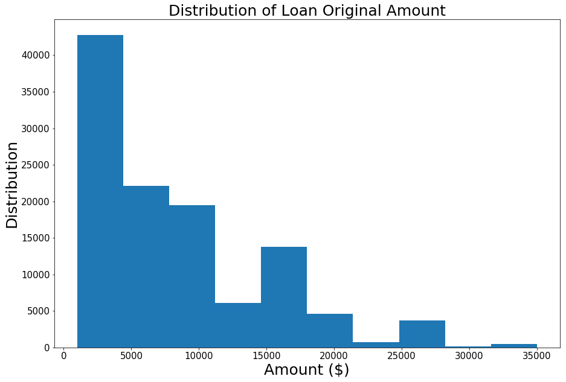

```python
# Visualization 1: Showing the distribution of loan amount

plt.figure(figsize = [15, 10])
plt.hist(data = df_loan, x ='LoanOriginalAmount')
plt.title('Distribution of Loan Original Amount', fontsize=25)
plt.xlabel('Amount ($)', fontsize = 25)
plt.ylabel('Distribution', fontsize = 25)
plt.yticks(fontsize=15)
plt.xticks(fontsize=15);
```

### Observation 1: From the above, a good measure of loan amounts taken fall between \$1,000 and \\$20,000, not many people took loans greater than \$20,000

### Question 2: What is the amount and frequency of monthly loan payments?

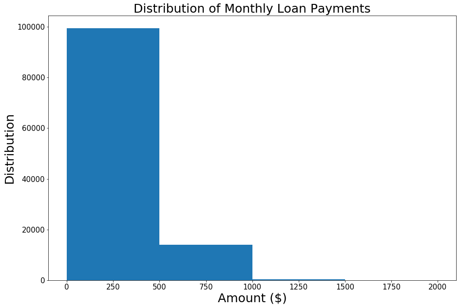

```python
# Visualization 2: Showing distribution of monthly loan payments

plt.figure(figsize = [15, 10])
bins = np.arange(0, df_loan['MonthlyLoanPayment'].max()+50, 500)
plt.hist(data = df_loan, x ='MonthlyLoanPayment', bins=bins)
plt.title('Distribution of Monthly Loan Payments', fontsize=25)
plt.xlabel('Amount ($)', fontsize = 20)
plt.ylabel('Distribution', fontsize = 20)
plt.yticks(fontsize=12)
plt.xticks(fontsize=12);
```

### Question 3: Did employment status affect loans granted?

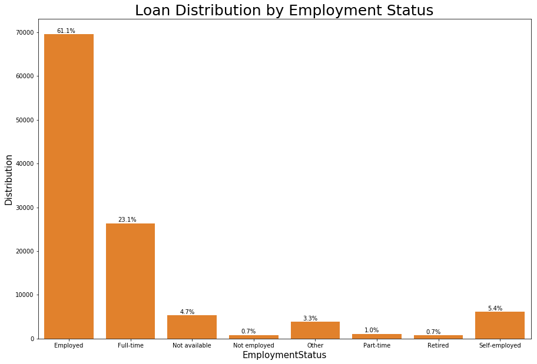

```python
# Visualization 3: Show distribution of employment status

plt.figure(figsize = [15, 10])
n_status=df_loan['EmploymentStatus'].value_counts().sum()
base_color = sb.color_palette()[1]

sb.countplot(data=df_loan, x='EmploymentStatus', color=base_color)
plt.title('Loan Distribution by Employment Status', fontsize=25)
plt.xlabel('EmploymentStatus', fontsize = 15)
plt.ylabel('Distribution', fontsize = 15)
plt.yticks(fontsize=12)
plt.xticks(fontsize=12)

status_counts = df_loan['EmploymentStatus'].value_counts()

for i in range(status_counts.shape[0]):
    count = status_counts[i]
    pct_string = '{:0.1f}%'.format(100*count/n_status)
    plt.text(i-0.2,count+700, pct_string, va = 'center');
plt.show()
```

### Observation 3: More loans were given to people who indicated some kind of employment (Employed, Fulltime, self-employed)

### Question 4: Did borrower location affect the disbursement of loans?

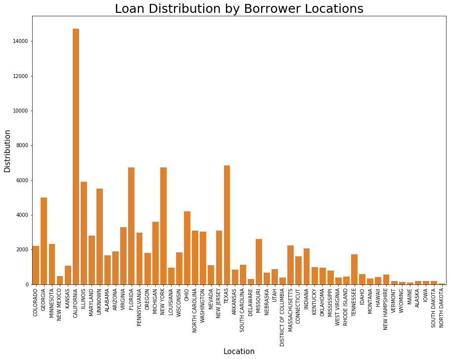

```python
# Visualization 4: showing distribution of borrower locations

plt.figure(figsize = [15, 10])
base_color = sb.color_palette()[1]
sb.countplot(data= df_loan, x='BorrowerState', color=base_color)
plt.title('Loan Distribution by Borrower Locations', fontsize=25)
plt.xlabel('Location', fontsize = 15)
plt.ylabel('Distribution', fontsize = 15)
plt.yticks(fontsize=12)
plt.xticks(fontsize=12)
plt.xticks(rotation=90);
```

### Observation 4: From the above, California had the highest number of borrowers, Florida, New York, Texas were also prominent in the graph above

### Question 5: What was the distribution of loan performance in the data set?

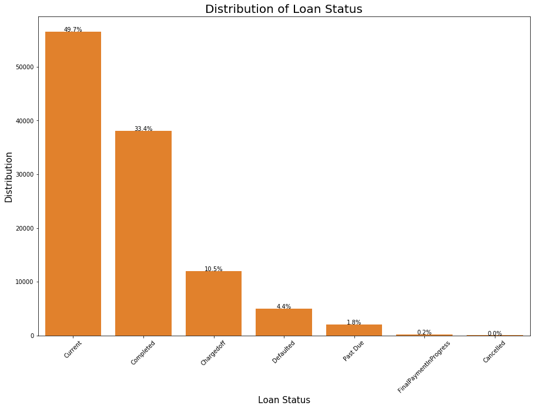

```python
# Visualization 5: Distribution to show loan status

plt.figure(figsize = [15, 10])

n_loans=df_loan['LoanStatus'].value_counts().sum()
status_count=df_loan['LoanStatus'].value_counts()
status_order=status_count.index

base_color = sb.color_palette()[1]
sb.countplot(data=df_loan, x='LoanStatus', color=base_color, order=status_order)
plt.title('Distribution of Loan Status', fontsize=20)
plt.xlabel('Loan Status', fontsize = 15)
plt.ylabel('Distribution', fontsize = 15)
plt.yticks(fontsize=12)
plt.xticks(fontsize=12)

locs, labels = plt.xticks(rotation=45)
# loop through each pair of locations and labels
for loc, label in zip(locs, labels):
    # get the text property for the label to get the correct count
    count = status_count[label.get_text()]
    pct_string = '{:0.1f}%'.format(100*count/n_loans)

    # print the annotation just below the top of the bar
    plt.text(loc, count+2, pct_string, ha = 'center', color = 'black')
```

### Observation 5: Loan performance is not bad, about 49.7% of the loans are current while 33.4% of the loans have been completed. Default loans account for about 4.4% of the data set, while about 10.5% of the loans have been written off

### Question 6: Does income range affect loan requests?

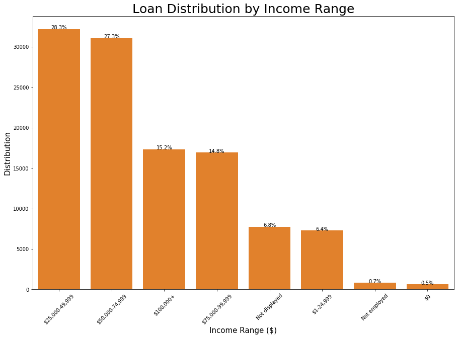

```python
# Visualization 6: Showing distribution of income range

plt.figure(figsize = [15, 10])

inc_range =df_loan['IncomeRange'].value_counts().sum()
status_count=df_loan['IncomeRange'].value_counts()
status_order=status_count.index


base_color = sb.color_palette()[1]
sb.countplot(data=df_loan, x='IncomeRange', color=base_color, order=status_order)
plt.title('Loan Distribution by Income Range', fontsize=25)
plt.xlabel('Income Range ($)', fontsize = 15)
plt.ylabel('Distribution', fontsize = 15)
plt.yticks(fontsize=12)
plt.xticks(fontsize=12)

locs, labels = plt.xticks(rotation=45)
# loop through each pair of locations and labels
for loc, label in zip(locs, labels):
    # get the text property for the label to get the correct count
    count = status_count[label.get_text()]
    pct_string = '{:0.1f}%'.format(100*count/inc_range)

    # print the annotation just below the top of the bar
    plt.text(loc, count+2, pct_string, ha = 'center', color = 'black')
```

### Observation 6: Middle income earners (i.e \$25k -\\$49.9k and \$50k -\\$74.9k) took more loans than the high income earners (\$75k-\\$99k and \$100k +)

### Question 7: What is the breakdown of loans taken per year?

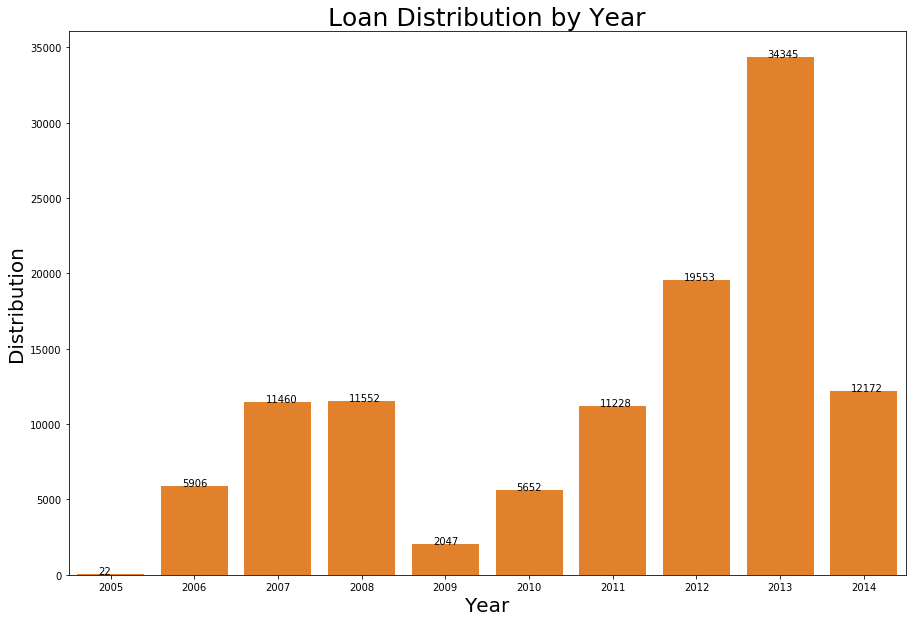

```python
# Visualization 7: Plot to show breakdown of loans taken per year


plt.figure(figsize = [15, 10])

ax = sb.countplot(data=df_loan, x='Year', color=base_color)
plt.title('Loan Distribution by Year', fontsize=25)
plt.xlabel('Year', fontsize = 20)
plt.ylabel('Distribution', fontsize = 20)
plt.yticks(fontsize=12)
plt.xticks(fontsize=12)

for p in ax.patches:
    ax.annotate('{:.0f}'.format(p.get_height()), (p.get_x()+0.25, p.get_height()+0.01))

plt.show()
```

### Observation 7: Amount of Loans taken experienced an increase in 2007 and 2008 from year 2006. However, the amount declined in 2009. An increase was noticed in the coming years, the peak being year 2013, after which there was a drop in 2014

### Question 8: Did Prosper Rating (Alpha) affect loan grants?

```python
#Creating a dataframe where month is after July 2009 since Prosper Rating (Alpha) became applicable after July 2009

after_july = df_loan.loc[df_loan['Month'].isin([8,9,10,11,12]) & (df_loan['Year'].isin([2009,2010,2011,2012,2013,2014]))]
after_july.head()
```

|  | Term | LoanStatus | ProsperRating (Alpha) | ProsperScore | BorrowerState | Occupation | EmploymentStatus | IncomeRange | Recommendations | LoanOriginalAmount | Year | LoanCurrentDaysDelinquent | StatedMonthlyIncome | IsBorrowerHomeowner | MonthlyLoanPayment | Month |
| --- | --- | --- | --- | --- | --- | --- | --- | --- | --- | --- | --- | --- | --- | --- | --- | --- |
| 3 | Medium | Current | A | 9 | GEORGIA | Skilled Labor | Employed | $25,000-49,999 | 0 | 10000 | 2012 | 0 | 2875.000000 | True | 321.45 | 11 |
| 4 | Medium | Current | D | 4 | MINNESOTA | Executive | Employed | $100,000+ | 0 | 15000 | 2013 | 0 | 9583.333333 | True | 563.97 | 9 |
| 5 | Long | Current | B | 10 | NEW MEXICO | Professional | Employed | $100,000+ | 0 | 15000 | 2013 | 0 | 8333.333333 | True | 342.37 | 12 |
| 8 | Medium | Current | AA | 9 | ILLINOIS | Food Service | Employed | $25,000-49,999 | 0 | 10000 | 2013 | 0 | 3333.333333 | True | 305.54 | 12 |
| 9 | Medium | Current | AA | 1 | ILLINOIS | Food Service | Employed | $25,000-49,999 | 0 | 10000 | 2013 | 0 | 3333.333333 | True | 305.54 | 12 |

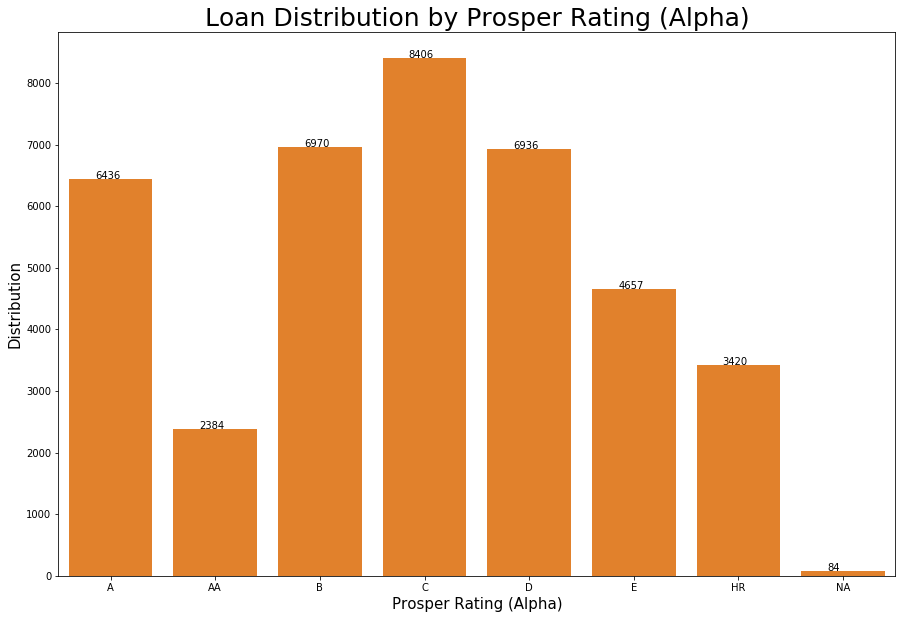

```python
plt.figure(figsize = [15, 10])
base_color = sb.color_palette()[1]
ax= sb.countplot(data=after_july, x='ProsperRating (Alpha)', color=base_color)
plt.title('Loan Distribution by Prosper Rating (Alpha)', fontsize=25)
plt.xlabel('Prosper Rating (Alpha)', fontsize = 15)
plt.ylabel('Distribution', fontsize = 15)
plt.yticks(fontsize=12)
plt.xticks(fontsize=12)

for p in ax.patches:
    ax.annotate('{:.0f}'.format(p.get_height()), (p.get_x()+0.25, p.get_height()+0.01))

plt.show()
```

### Question 9: What was the risk associated with loans granted?

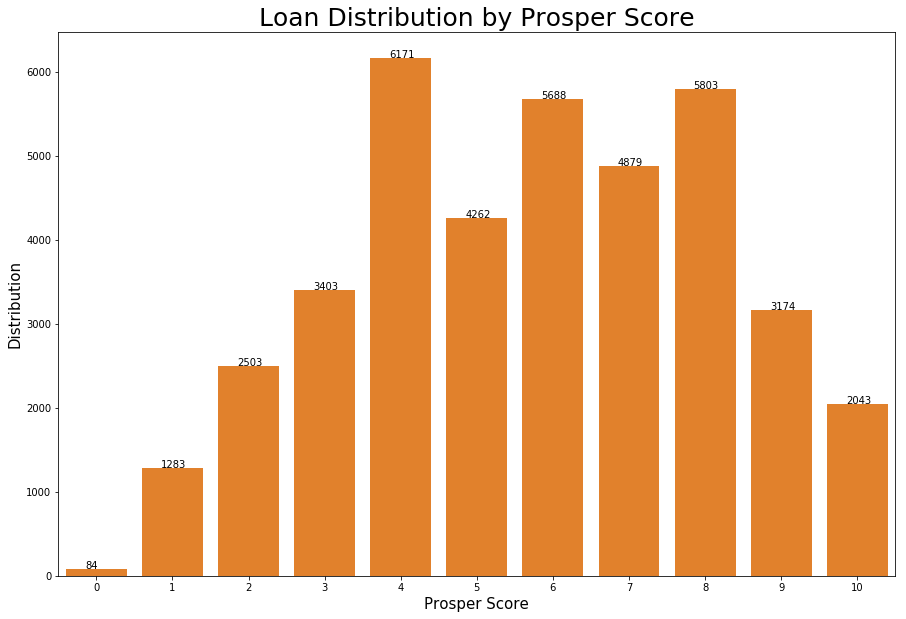

```python
# Visualization 9: plot to show Risk rating of loans

plt.figure(figsize = [15, 10])
base_color = sb.color_palette()[1]
ax= sb.countplot(data=after_july, x='ProsperScore', color=base_color)
plt.title('Loan Distribution by Prosper Score', fontsize=25)
plt.xlabel('Prosper Score', fontsize = 15)
plt.ylabel('Distribution', fontsize = 15)
plt.yticks(fontsize=10)
plt.xticks(fontsize=10)

for p in ax.patches:
    ax.annotate('{:.0f}'.format(p.get_height()), (p.get_x()+0.25, p.get_height()+0.01))

plt.show()
```

### Question 10: Did number of recommendations affect loans granted?

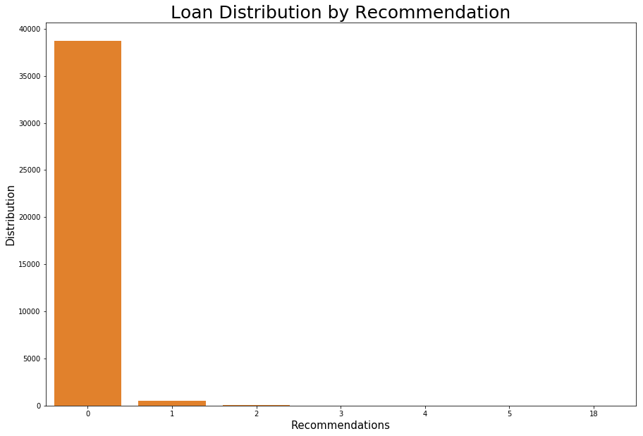

```python
# Visualization 10 : Plot to show loan distribution by recommendation

plt.figure(figsize = [15, 10])
base_color = sb.color_palette()[1]
sb.countplot(data=after_july, x='Recommendations', color=base_color)
plt.title('Loan Distribution by Recommendation', fontsize=25)
plt.xlabel('Recommendations', fontsize = 15)
plt.ylabel('Distribution', fontsize = 15)
plt.yticks(fontsize=10)
plt.xticks(fontsize=10);
```

### Observation 10: From the above, it can be seen that number of recommendations presented did not affect loans disbursed

### Question 11: Did home ownership affect loan disbursement?

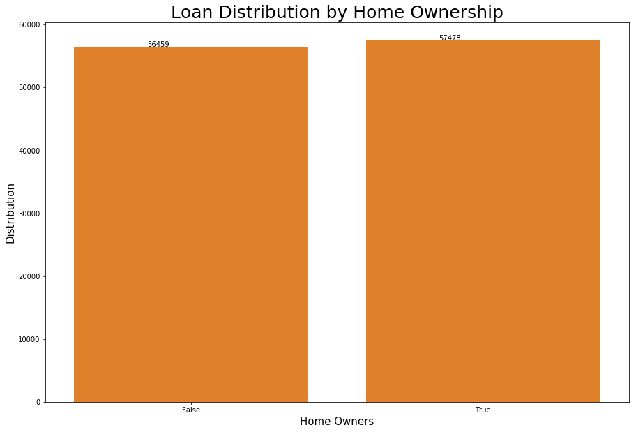

```python
plt.figure(figsize = [15, 10])
base_color = sb.color_palette()[1]
ax= sb.countplot(data=df_loan, x='IsBorrowerHomeowner', color=base_color)
plt.title('Loan Distribution by Home Ownership', fontsize=25)
plt.xlabel('Home Owners', fontsize = 15)
plt.ylabel('Distribution', fontsize = 15)
plt.yticks(fontsize=10)
plt.xticks(fontsize=10)

for p in ax.patches:
    ax.annotate('{:.0f}'.format(p.get_height()), (p.get_x()+0.25, p.get_height()+0.01))
```

### Observation 11: From the above, it shows that home ownership didn't affect loans granted as 56,459 loans were given to people who did not own homes while 57,478 loans were given to home owners

### Question 12: What was the distribution of loan amounts granted?

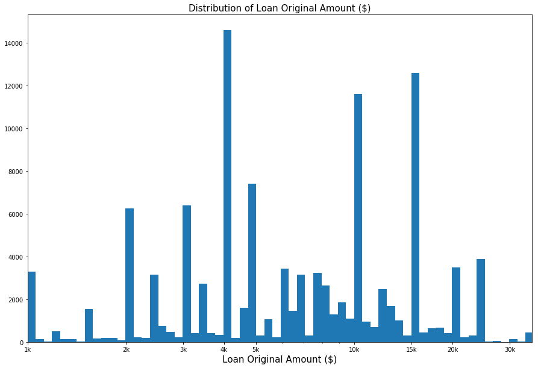

```python
# plot to show loan original amount against a log scale
plt.figure(figsize = [15, 10])
log_binsize = 0.025
bins_log = 10 ** np.arange(3, np.log10(df_loan['LoanOriginalAmount'].max())+log_binsize, log_binsize)
plt.hist(data = df_loan, x = 'LoanOriginalAmount', bins = bins_log)
plt.xscale('log')
x_ticks = [1000, 2000, 3000, 4000, 5000, 10000, 15000,20000, 30000]
x_ticks_names = ['1k','2k', '3k', '4k', '5k', '10k','15k', '20k','30k']
plt.xticks(x_ticks, x_ticks_names)
plt.xlim((1000,35000))
plt.xlabel('Loan Original Amount ($)', fontsize=15)
plt.title('Distribution of Loan Original Amount ($)', fontsize=15);
```

### Summary

- Most of the loans granted didn't have any recommendations

- Prosper Score '4' and Prosper Rating (Alpha) 'C' were given to most loans disbursed from 2009 t0 2014

- 2013 had the highest disbursement of loans

- Middle income earners (i.e \$25k -\$49.9k and \$50k -\$74.9k) took more loans

- Almost 50\% of the loans are currently running

- California had the highest number of borrowers

- The wrangling process was performed on certain variables to make them tidy for analysis and visualization

## Bivariate Exploration

This section shows the relationship between pairs of variables used for the univariate exploration

### Question 13: Does employment status influence prosper score?

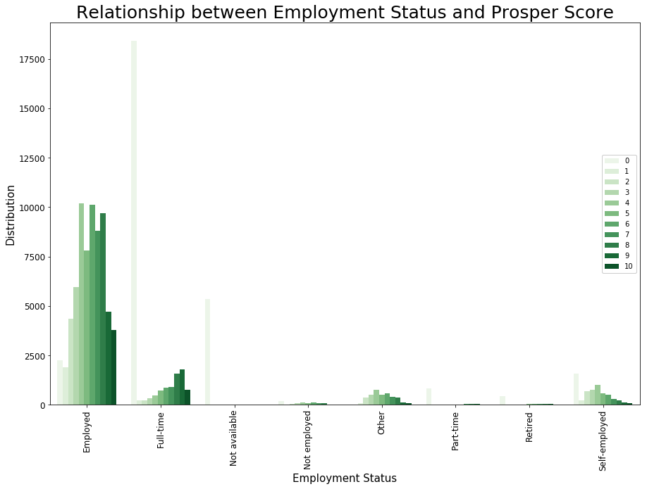

```python
# Visualization 13: plot to show relationship between employment status and prosper score

plt.figure(figsize = [15, 10])
ax= sb.countplot(data= df_loan, x= 'EmploymentStatus', hue='ProsperScore', palette= 'Greens')
ax.legend(loc=5, framealpha = 1)
plt.title('Relationship between Employment Status and Prosper Score', fontsize=25)
plt.xlabel('Employment Status', fontsize = 15)
plt.ylabel('Distribution', fontsize = 15)
plt.yticks(fontsize=12)
plt.xticks(fontsize=12)
plt.xticks(rotation=90);
```

### Observation 13: '10' is the best prosper score and it is assigned to loans with the lowest risk, from above this featured majorly in the Employed and full time catergory. It is safe to assume that it is because they have a steady source of repayment

### Question 14: Does employment status influence home ownership?

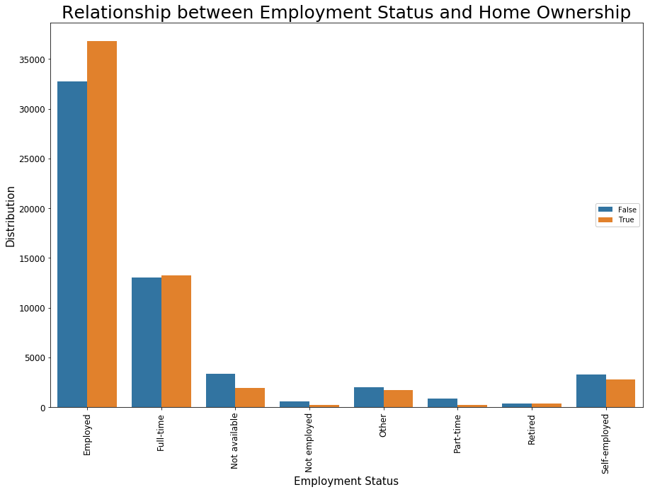

```python
# Visualization 14: plot to show relationship between employment status and home ownership

plt.figure(figsize = [15, 10])
ax= sb.countplot(data= df_loan, x= 'EmploymentStatus', hue= 'IsBorrowerHomeowner')
ax.legend(loc=5, framealpha =1)
plt.title('Relationship between Employment Status and Home Ownership', fontsize =25)
plt.xlabel('Employment Status', fontsize = 15)
plt.ylabel('Distribution', fontsize = 15)
plt.yticks(fontsize=12)
plt.xticks(fontsize=12)
plt.xticks(rotation=90);
```

### Observation 14: A good amount of individuals in the employment status groups are home owners, except for the 'Not employed' and 'Part time' categories which is understandable

### Question 15: Is there a relationship between loan original amount and monthly loan payment?

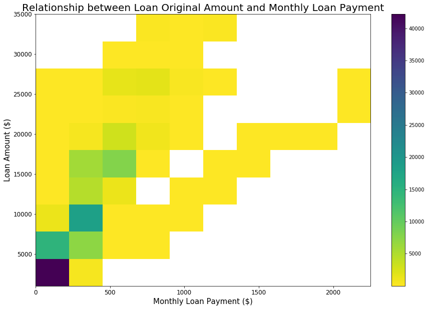

```python
# Visualization 15: 2D histogram plot between loan original amount and monthly loan payment

plt.figure(figsize = [15, 10])
bins_x = np.arange(0, 2500, 200)
bins_y = np.arange(350, 35000+350, 350)

plt.hist2d(data = df_loan, x = 'MonthlyLoanPayment', y = 'LoanOriginalAmount', cmin=0.5, cmap='viridis_r')
plt.colorbar()
plt.xlabel('Monthly Loan Payment ($)', fontsize = 15)
plt.ylabel('Loan Amount ($)', fontsize = 15)
plt.yticks(fontsize=12)
plt.xticks(fontsize=12)
plt.title('Relationship between Loan Original Amount and Monthly Loan Payment', fontsize=20);
```

### Observation 15: From the above, the top of the diagram has more brighter yellow points. This shows that the higher the monthly loan payments, the higher the loan original amount. This means that there is a positive corellation between the two variables

### Question 16: Is there a relationship between loan original amount and term of loan?

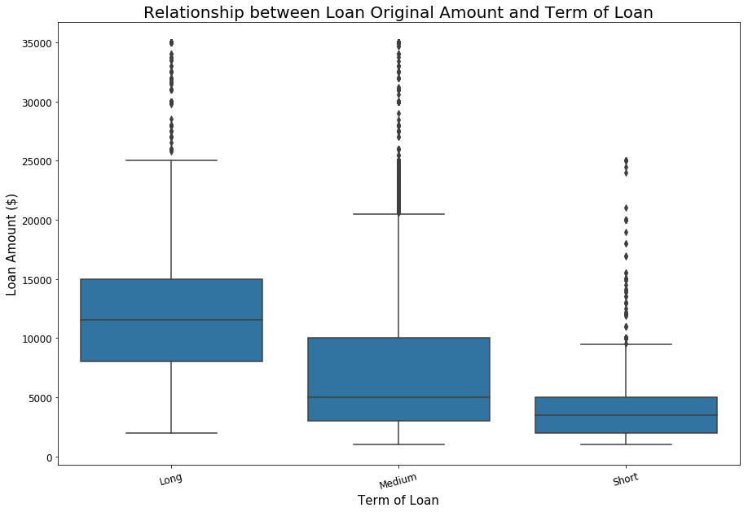

```python
# Visualization 16: Box plot to visualize relationship between loan original amount and term of loan

plt.figure(figsize = [15, 10])
base_color = sb.color_palette()[0]
sb.boxplot(data=df_loan, x='Term', y='LoanOriginalAmount', color=base_color)
plt.xticks(rotation=15)
plt.xlabel('Term of Loan', fontsize = 15)
plt.ylabel('Loan Amount ($)', fontsize = 15)
plt.yticks(fontsize=12)
plt.xticks(fontsize=12)
plt.title('Relationship between Loan Original Amount and Term of Loan', fontsize=20);
```

### Observation 16: The lower, middle and upper quartiles are in ascending order from the short to medium and long term of the loans. The figure shows loan amounts impact term of loans as larger loan amounts have longer durations for repayment

### Question 17: Is there a relationship between the numeric values in the dataset?

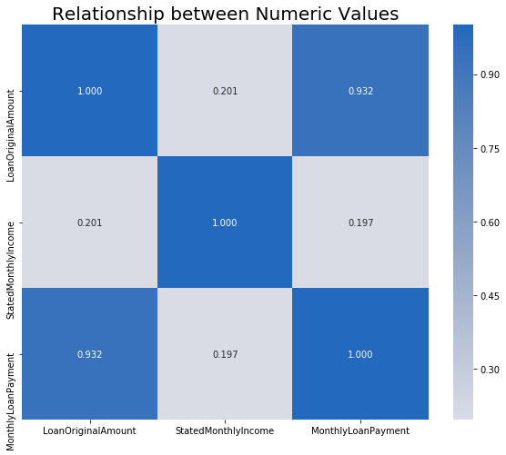

```python
# Visualization 17: Heat map to show correlation between variables

numeric_vars = ['IncomeRange', 'LoanOriginalAmount', 'StatedMonthlyIncome', 'MonthlyLoanPayment']

plt.figure(figsize = [10, 8])
sb.heatmap(df_loan[numeric_vars].corr(), annot = True, fmt = '.3f',
           cmap = 'vlag_r', center = 0)

plt.title('Relationship between Numeric Values', fontsize =20)

plt.show()
```

### Observation 17: There is a stronger relationship between loan original amount and monthly loan payment when compared to the other variables. An increase in one causes an increase in the other variable

### Question 18: How was loan performance over the years?

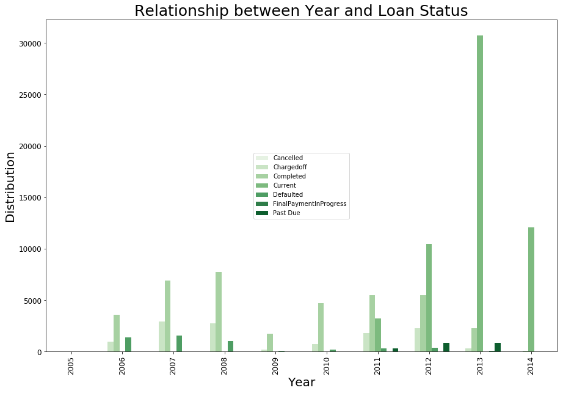

```python
# Visualization 18: plot to show loan performance over the years

plt.figure(figsize = [15, 10])
ax= sb.countplot(data= df_loan, x= 'Year', hue= 'LoanStatus', palette = 'Greens')
ax.legend(loc=10)
plt.title('Relationship between Year and Loan Status', fontsize =25)
plt.xlabel('Year', fontsize = 20)
plt.ylabel('Distribution', fontsize = 20)
plt.yticks(fontsize=12)
plt.xticks(fontsize=12)
plt.xticks(rotation=90);
```

### Summary of Bivariate Exploration

- It was observed that loan amount (the feature of interest) had a strong relationship with monthly payments, the higher the monthly payment, the higher the loan amount. Also higher loan amounts had longer payment duration

- Loan performance was good over the years, as more loans were still current or completed when compared to the number of charged offs or defaulting loans

## Multivariate Exploration

This section makes use of plots of three or more variables to provide further insights into the data set

### Question 19: How will the loan performance be described so far?

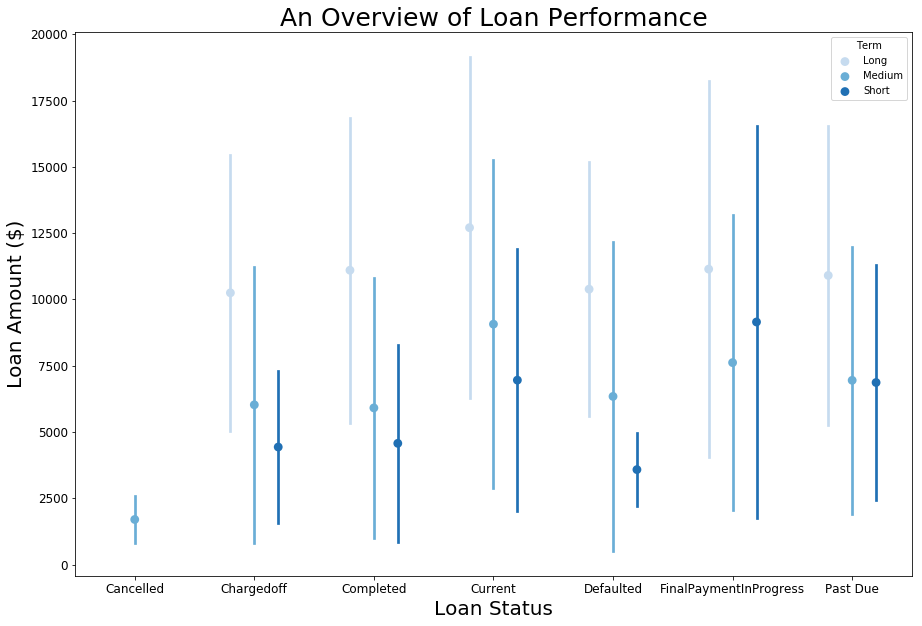

```python
# Visualization 19: plot to show loan performance

fig = plt.figure(figsize = [15,10])
ax = sb.pointplot(data = df_loan, x = 'LoanStatus', y = 'LoanOriginalAmount', hue = 'Term',
           palette = 'Blues', linestyles = '',dodge = 0.4, ci='sd')

plt.title('An Overview of Loan Performance', fontsize =25)
plt.yticks(fontsize=12)
plt.xticks(fontsize=12)
plt.xlabel('Loan Status', fontsize = 20)
plt.ylabel('Loan Amount ($)', fontsize = 20);
```

### Observation 19: The plot above shows a summary of the performance of the loan books using loan status and term. Performance is not bad as the total points for completed, current and final payments is more than the sum of cancelled, charged off, defaulted and past due loans.

### Question 20: Did home ownership influence loan amounts granted?

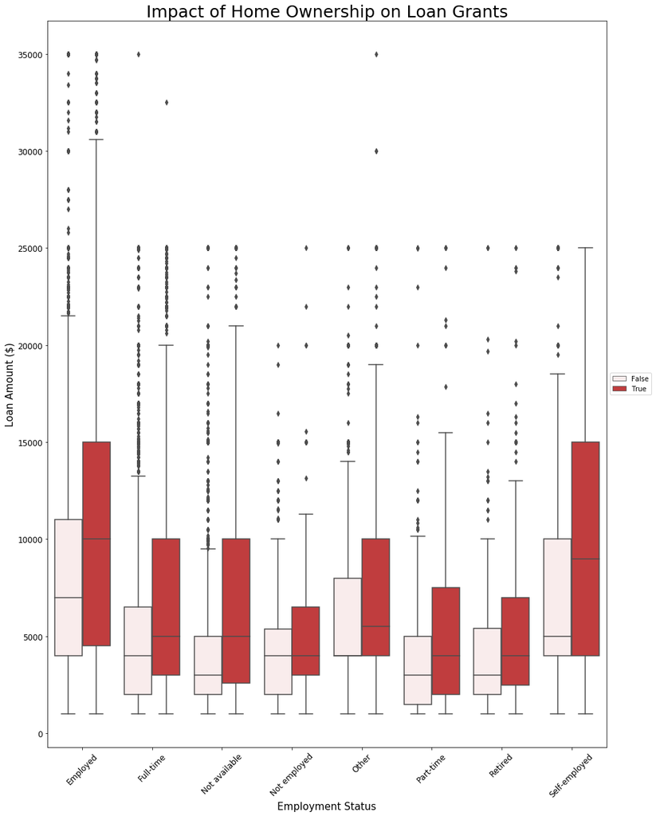

```python
# Visualization 20: Plot to show the impact of home ownership and employment status on loan amount

plt.figure(figsize=[15, 20])
color_base= sb.color_palette()[3]
sb.boxplot(data=df_loan,x='EmploymentStatus',y='LoanOriginalAmount',hue='IsBorrowerHomeowner',dodge=0.3, color=color_base)
plt.title('Impact of Home Ownership on Loan Grants', fontsize =25)
plt.xlabel('Employment Status', fontsize = 15)
plt.ylabel('Loan Amount ($)', fontsize = 15)
plt.yticks(fontsize=12)
plt.xticks(fontsize=12)
plt.xticks(rotation=45);
plt.legend(loc = 6, bbox_to_anchor = (1.0, 0.5));
```

### Observation 20: From the above, home owners were given higher loan amounts across the various employment categories

### Question 21: Did income range affect loan duration?

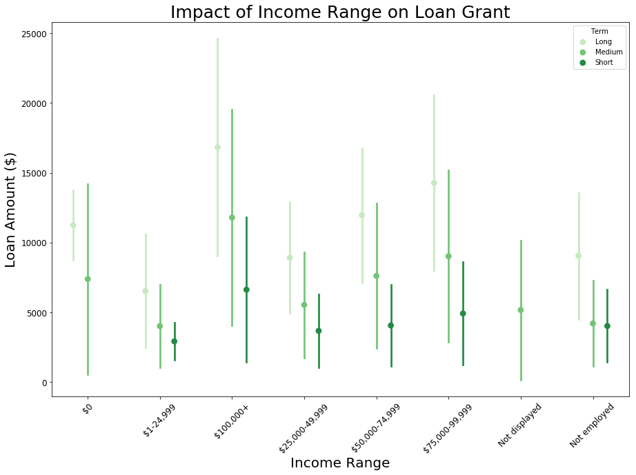

```python
# Visualization 21: plot to show impact of income range on loan amount

fig = plt.figure(figsize = [15,10])
ax = sb.pointplot(data = df_loan, x = 'IncomeRange', y = 'LoanOriginalAmount', hue = 'Term',
           palette = 'Greens', linestyles = '',dodge = 0.4, ci='sd')

plt.title('Impact of Income Range on Loan Grant', fontsize =25)
plt.yticks(fontsize=12)
plt.xticks(fontsize=12)
plt.xticks(rotation=45)
plt.xlabel('Income Range', fontsize = 20)
plt.ylabel('Loan Amount ($)', fontsize = 20);
```

### Question 22: What is relationship between the variables in the dataset?

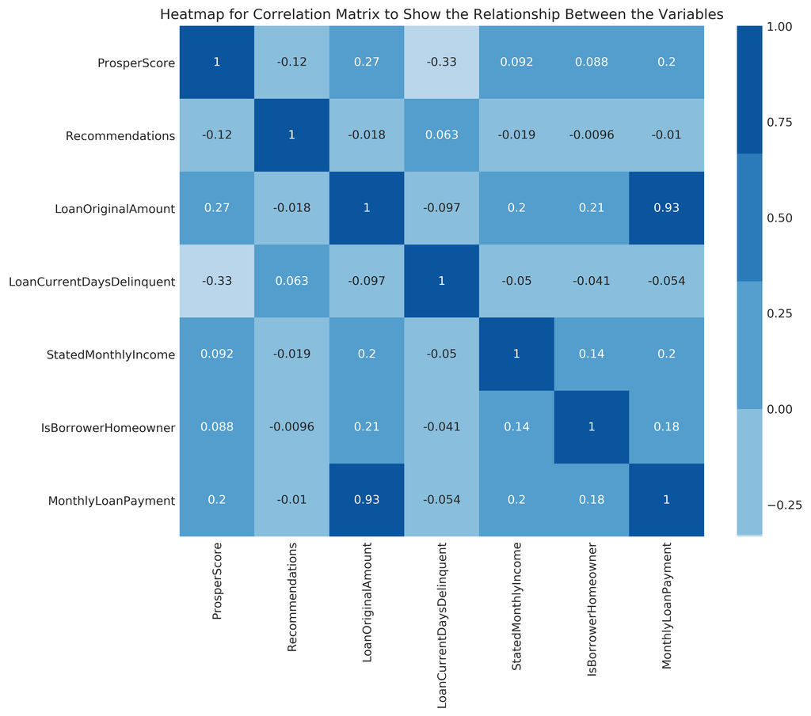

```python
# Visualization 22: heatmap plot to show correlation between the variables in the dataset
sb.set_style('darkgrid')
sb.set_palette("Set2", 8, .75)
plt.figure(figsize=(10,8), dpi = 400)
colormap = sb.color_palette('Blues')
sb.heatmap(df_loan.corr(), annot = True, cmap = colormap, center = 0)
plt.title('Heatmap for Correlation Matrix to Show the Relationship Between the Variables');
```

### Observation 22: From the above, Monthly Loan Payment and Loan Original Amount had the strongest correlection. This confirms that an increase in one variable caused an increase in the other

### Summary of Multivariate Exploration

- Investigations showed a strong positive correlation between loan original amount and monthly loan payment, an increase in one caused an increase in the other

- Home owners were given more loan amounts across the various employment statues

- Performance is not bad as the total points for completed, current and final payments is more than the sum of cancelled, charged off, defaulted and past due loans

- It was surprising that some \$0 income earners had some long and medium term loans

### Conclusions

From the above explorations, the following were deduced:

- Employment Status played a role in getting loan grants as majority of loans granted were for individuals with some kind of employment and their home ownerships also influenced the loans granted to them

- California, Florida, New York, Texas were locations where more loans were disbursed

- Over 80\% of the loans were either currently running or completed

- 2013 had the highest disbursement of loans

- Middle income earners (i.e \$25k -\$49.9k and \$50k -\$74.9k) took more loans and higher loan amounts were usually accompanied by higher monthly repayments

In addition to the above, the following wrangling efforts were carried out on the following features in the data set:

- Term of the loan:This was renamed into short, medium and long term. The data type was also converted to category

- Current Status of the loan: The past due dates were converted into a general category tagged 'past due'. The data type of the column was also changed to category

- Ratings and Scores: The nulls were filled and the data type was converted to category and int respectively

- Location: The nulls were filled and the data type was converted to category. Abbreviated states were also changed to the full names of these locations

- Occupation: The nulls were filled and the data type was converted to category

- Employment status: The nulls were filled and the data type was converted to category

- Income Range: The data type was converted to category